# Report

## Exploratory Data Analysis

### Histograms

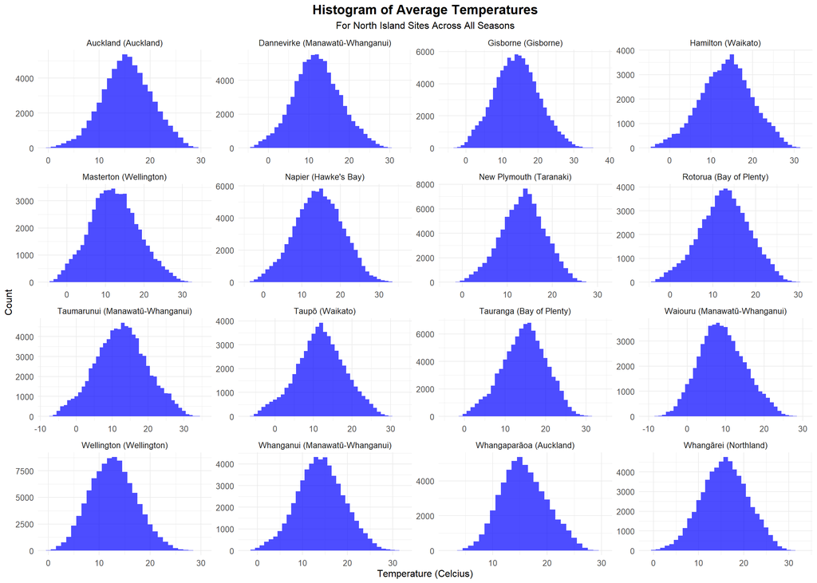

Figure 1: Histogram of average temperatures for North Island sites across all seasons, using a binwidth of 1, Each subplot represents one site for visual comparison of temperature distribution

##### **Observations:**

**Shape and Symmetry:** Temperature distributions across many sites such as Auckland (Auckland), Hamilton (Waikato), and Wellington (Wellington) exhibit bell-shaped curves indicative of normal distributions. This data indicates that temperatures tend to cluster around a central mean, with two equally likely extreme temperature distributions on either side of it. Waiouru in Manawatu-Whanganui and Rotorua in Bay of Plenty deviate slightly from this pattern in their distribution patterns; here the distributions appear somewhat irregular. Waiouru shows mild negative skewness (left skew), with longer tails on lower temperature sides; Rotorua shows slight positive skewness (right skew), with longer tails at higher temperature sides. Though these levels of skewness aren’t drastic, they suggest these sites experience more frequent extreme temperatures on one end of their temperature spectrum than another.

**Temperature range:** For most sites, the temperature range is from around 0°C to 30°C. However, Waiouru (in Manawatū-Whanganui) and Taumarunui (also in Manawatū-Whanganui) have distributions that extend well into the negative range, which means they occasionally experience average temperatures below freezing, most likely in the winter months. This indicates that these two areas are much more likely to experience extremes on the cold side of the spectrum compared to other locations on the North Island.

### Boxplots per season

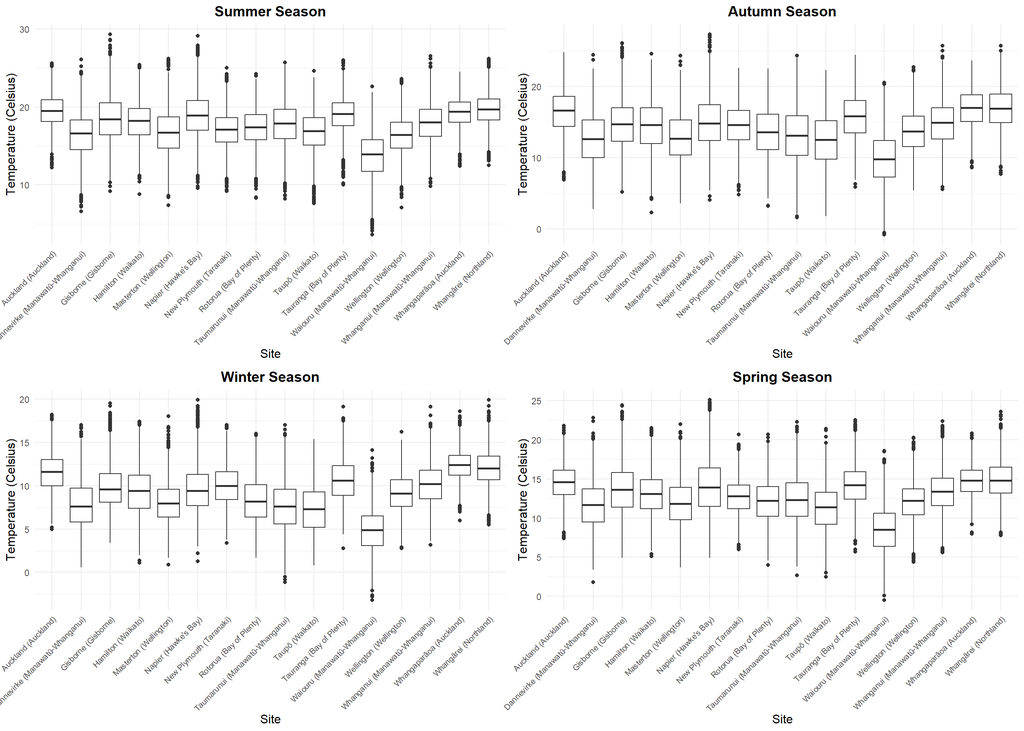

Figure 2: Boxplots of average temperatures for North Island sites across all seasons.

##### **Summer:**

The highest median temperatures, normally between 15ºC and 22ºC, are found in the summer. In this season, places such as the coastal Northland city of Whangarei and the Bay of Plenty city of Tauranga enjoy their median warmest temperatures. On the other hand, inland summer sites such as Waiouru (Manawatū-Whanganui) do not come close to the kinds of temperatures experienced at these northern coastal towns.

##### **Autumn:**

Autumn serves as an indicator of winter’s approach, with median temperatures generally falling from the high summer temperatures of 10ºC-15ºC across all sites and coastal regions experiencing slightly higher median temps compared to inland locations - this seasonal shift provides clear warning of its approach.

##### **Winter:**

The winter months, when median temperatures are between 5°C and 12°C, are the coldest in most parts of the North Island. Areas such as Taupo (Waikato) and Waiouru (Manawatū-Whanganui) are some of the coldest places in the North Island during this time, hitting median temperatures closer to 5°C. The IQR for this season is the narrowest of any season, indicating that it is mostly stable but mostly cold. The IQR is slightly lower in Auckland (Auckland) and Whangarei (Northland) because these coastal areas are likely experiencing the milder conditions associated with the ocean’s moderating effect. We noted above that Waiouru has significant outliers that hit below 0°C, implying these numbers reflect a few times when it was freezing cold across these sites - a common occurrence in this region of the North Island.

### Correlation Matrix

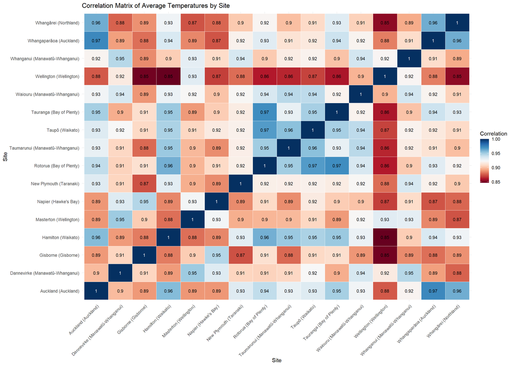

Figure 6: Correlation Matrix of Average Temperatures by Site.

The average temperature correlation matrix for North Island sites provides some clear signals about the temperature relationships among these locations. Most of the correlation coefficients fall within a rather narrowly defined range of 0.85 to 1.00. The sites’ temperatures tend to move in tandem, indicating that they’re under the influence of the same (or very similar) set of climatic factors and yielding a pretty well-defined and cohesive temperature pattern across the North Island.

However, there are some notable deviations. One of them is Wellington, which has somewhat lower correlations with other sites, sometimes dipping as low as 0.85. This might reflect the way Wellington’s geography, with its urban topography and coastal-wind conditions, partly determines a rather special microclimate. Another site with lower correlations is Gisborne; its location on the east coast, with its somewhat sheltered situation, probably also allows it to indulge in a special microclimate. On the other hand, locations in the central North Island—such as Hamilton (Waikato), Rotorua (Bay of Plenty), and Taupō (Waikato)—show very strong correlations that are often near 1.00. The sites have similar environmental conditions, which accounts for the similarity of their temperature patterns.

In general, this matrix of correlations highlights the vigorous temperature relationships at the majority of North Island sites. A few exceptions can be attributed to geographical and climatic factors that provide effective explanations for them.

#### Time Series

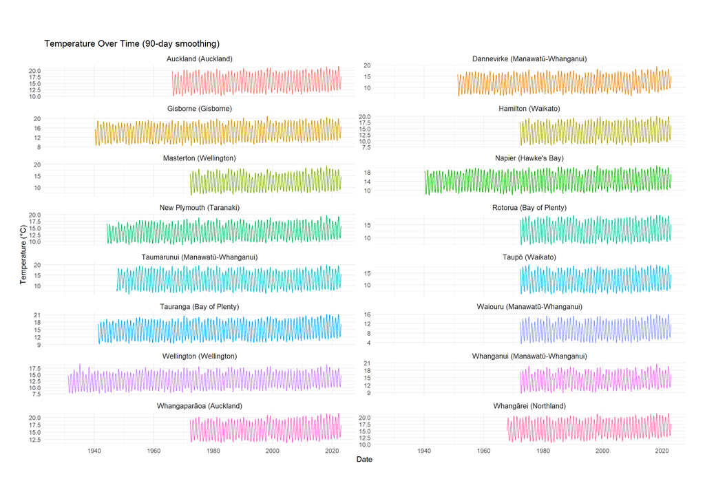

Figure 7: Temperature Over Time (90-day smoothing) by Site.

#### Individual Contributions

##### Arman

- **Histogram Analysis**: The histogram plots were designed, implemented, and analysed by Arman. He filtered the data, determined the bin widths, and wrote the analysis section that discusses the patterns and distributions observed in the data.
- **Boxplot Analysis**: The boxplot visualisations for the different seasons were created by Arman. He did the coding for the plots, made sure they represented temperature ranges across the sites appropriately, and interpreted the why of the seasonal differences. He did the detailed write-up of the boxplots, which highlight some of the important findings regarding temperature trends across different seasons.
- **Correlation Matrix Analysis**: Arman created a correlation matrix to explore relationships among temperature variations at various sites across North Island. He managed data processing, matrix calculation, visualisation and provided written analyses on temperature correlations among them.
- **General Contributions**: In addition to the specific duties noted above, Arman contributed to the Background and Data and the Ethics, Privacy, and Security sections of the report. These sections were developed collaboratively, with each team member providing input to achieve the necessary accuracy and completeness in explaining the data source, structure, and ethical aspects of our work.